# duvidas

- se S{AB} e T{CE}, weighet cut = AC+AE+BC+BE ?
  - sim ig
- devemos meter q parte do codigo no rreport? todo? só os algoritmos e dpois o resultado das complexidades ou assim? devemos meter la os grafos ou como foram gerados ou assim?
  - so se mete tp Intro bla bla, Problema é bla bla, Aplicado em bla bla, uma approach é ... outra é ... (pode se meter pseudo code), comparar as duas approachs.... conclusoes
  - max number of edges = n * (n-1)
- peso das edges aletorio ou calculado pela distancia entre os vertices ?
  - random entre tp 0 e 20
- o q é o V e o E do graph G(V,E) qual o formato deles?
- pode ser pt?
  - sim

# todo

criar funcao geradora de graficos (total vertices, % de edges) -> salva o grafico com nome "[totalV][%*1000]"

## 23 – Find a maximum weighted cut for a given undirected graph G(V, E), with n vertices and m edges. A maximum weighted cut of G is a partition of the graph's vertices into two complementary sets S and T, such that the sum of the weights of edges between the set S and the set T is as large as possible.

ent um grafo, duas particoes S e T

S = {A,B}

T = {C,E}

max weighted cut = max (AC + AE + BC + BE)

## Design and test an exhaustive search algorithm to solve one of the following graph problems, as well as another method using a greedy heuristic.

**exhaustive** pode ser

- recurrence em q - return max({A...}{...D} , {A...D}{...})
- iterative - compare {A}{...} {AB}{...} ... {A...}{Z}

penso q ambos seriam 2^n de complexidade pq arvore e n+n-1+n-2+...

$\ $

**greedy heurisitc** pode ser sorted weights e maior é AB, ent S = {A} T = {B}, segudo maior CD, ent S={AC} T={BD}, algo desse genero

mas se segundo maior é AC - S = {A} T = {BC} ::

- if A and C in S or T: pass
- if A in S or T: C to other
- if neither in: randomly select - could compare to already in vertices but to complex?

complexidade nlogn por causa do sort + n por iterar por cada um - logo complexidade final = nlogn

# Graphs for the Computational Experiments

- graph vertices are 2D points on the XOY plane, with integer valued coordinates between 1 and 1000.
- graph vertices should neither be coincident nor too close.
- the number of edges sharing a vertex is randomly determined.

Generate successively larger random graphs, with 4, 5, 6, … vertices, using your student number as seed.

For each fixed number of vertices, generate graph instances with 12.5%, 25%, 50% and 75% of the maximum number of possible edges for that number of vertices.

Suggestions:

• use Python’s NetworkX package: https://networkx.org/

• store each graph in a file to be used for the computational experiments.

Depending on the problem, it might be helpful to represent each graph by its adjacency matrix or by its incidence matrix or by any other representation you might consider useful.

It might also be useful to graphically visualize the problem instances and the computed solutions.

https://networkx.org/documentation/stable/tutorial.html

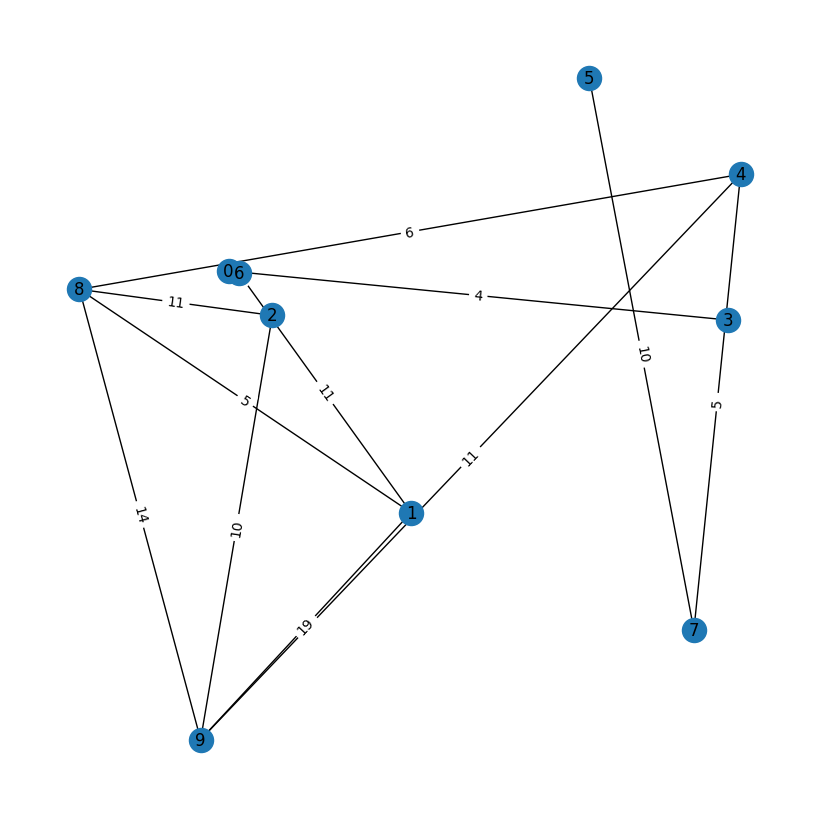

```python
import networkx as nx
import matplotlib.pyplot as plt
import random

# Parameters
n = 10  # Number of nodes
e = 0.125*n*(n-1)  # Number of edges
space_limit = 1000  # The limit for x and y coordinates in the 2D space

# Create a random graph with n nodes and e edges
G = nx.gnm_random_graph(n, e)

# Assign random (x, y) positions to each node in a 1000x1000 grid
positions = {i: (random.randint(0, space_limit), random.randint(0, space_limit)) for i in G.nodes()}

# Assign random weights to each edge
for (u, v) in G.edges():
    G[u][v]['weight'] = random.randint(1, 20)  # Random weight between 1 and 20

# Draw the graph with the node positions based on the coordinates
plt.figure(figsize=(8, 8))
edges = G.edges(data=True)

# Get edge weights
edge_weights = nx.get_edge_attributes(G, 'weight')

# Draw nodes and edges
nx.draw(G, pos=positions, with_labels=True)
nx.draw_networkx_edge_labels(G, pos=positions, edge_labels=edge_weights)

# Show the plot
plt.show()
```

```python
import networkx as nx
import itertools

def max_weight_cut(G):
    # Get all nodes from the graph
    nodes = list(G.nodes)
    n = len(nodes)

    # Initialize the best cut and the maximum weight
    max_cut_weight = 0
    best_partition = None

    # Brute force all possible partitions (2^n possible subsets)
    for i in range(1, 2 ** (n - 1)):  # We can check half the partitions (complement is equivalent)
        # Create partition sets S and its complement S_bar
        S = set(itertools.compress(nodes, map(int, bin(i)[2:].zfill(n))))
        S_bar = set(nodes) - S

        # Calculate the weight of the current cut
        cut_weight = sum(G[u][v]['weight'] for u, v in G.edges() if (u in S and v in S_bar) or (v in S and u in S_bar))

        # Update the maximum weight and the best partition
        if cut_weight > max_cut_weight:
            max_cut_weight = cut_weight
            best_partition = (S, S_bar)

    return best_partition, max_cut_weight

# Example usage
G = nx.gnm_random_graph(5, 7)  # Replace with your graph
# Assign random weights to edges
for (u, v) in G.edges():
    G[u][v]['weight'] = random.randint(1, 10)

best_partition, max_cut_weight = max_weight_cut(G)
print("Best Partition:", best_partition)
print("Maximum Cut Weight:", max_cut_weight)
```

```
Best Partition: ({1, 3}, {0, 2, 4})
Maximum Cut Weight: 33
```

tentar fazer recursivo ig, deve ser mais fixe